Datos públicos reales · Superintendencia Financiera de Colombia vía datos.gov.co · informe generado automáticamente con R

DIANA RODRÍGUEZ← Todos los bancos

INFORME MENSUAL · NOVIEMBRE 2026

# Banagrario: colocación de crédito

$378,5 mil millones

desembolsado en noviembre 2026

-71,7 %

frente a octubre 2026

1,5 %

del mercado · puesto 10 de 29

19,43 %

tasa ponderada E.A. (mercado 19,64 %)

## Lectura del mes

- En noviembre 2026, **Banagrario** desembolsó **$378,5 mil millones** en 29.966 créditos, una caída de 71,7 % frente a octubre 2026.
- Tiene el **1,5 %** de lo desembolsado por los bancos y ocupa el puesto 10 de 29. Desde enero 2026 su participación perdió 0,07 puntos porcentuales.
- Su principal línea es **Crédito productivo**, con el 58,8 % de su monto; ahí tiene el 30,1 % del mercado.
- Es más barato que el mercado en **Crédito productivo** (-17,55 pp) y **Consumo** (-2,98 pp).

La tasa total depende de la mezcla de productos: un banco con más consumo tendrá una tasa promedio más alta. Por eso la comparación justa es por tipo de crédito, en la segunda gráfica.

## Participación en el mercado, mes a mes

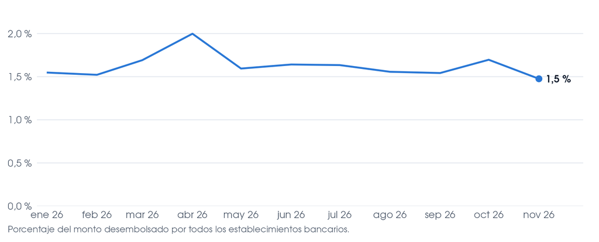

## Tasa por tipo de crédito: Banagrario frente al mercado

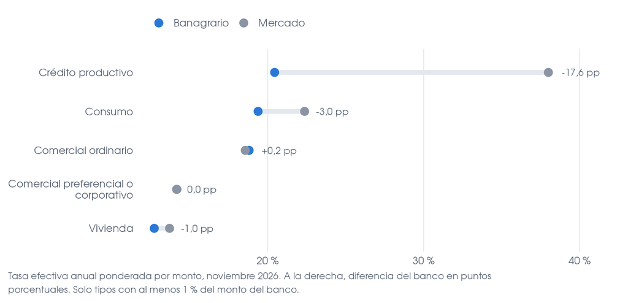

## En qué presta

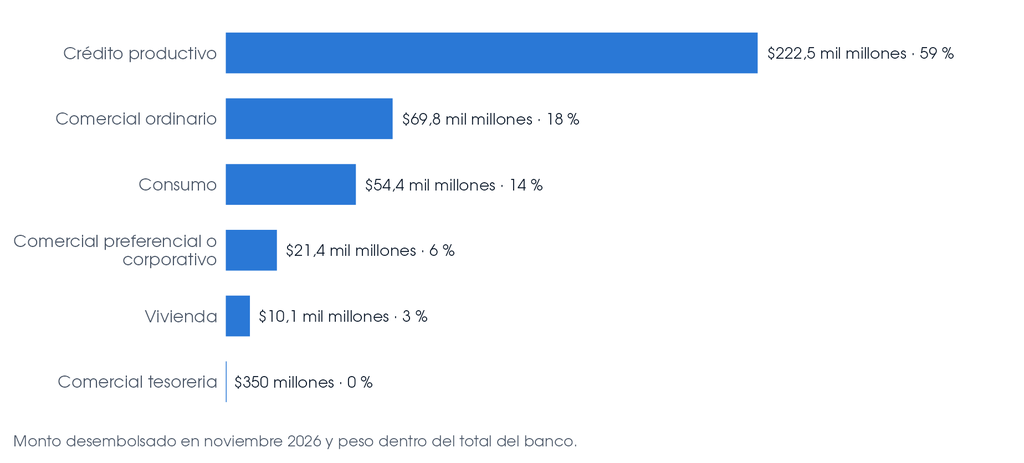

## Principales productos del mes

| Producto | Monto | Participación en el producto | Tasa banco | Tasa mercado | Diferencia |
| --- | --- | --- | --- | --- | --- |
| Crédito productivo rural (con recursos de redescuento) | $64,3 mil millones | 99,9 % | 17,38 % | 17,39 % | -0,01 pp |
| Crédito productivo urbano (con recursos de redescuento) | $47,9 mil millones | 99,0 % | 17,44 % | 17,72 % | -0,28 pp |
| Otros comercial | $42,8 mil millones | 78,6 % | 18,39 % | 17,76 % | +0,62 pp |
| Crédito productivo de mayor monto (con recursos de redescuento) | $40,4 mil millones | 96,8 % | 18,17 % | 18,30 % | -0,13 pp |
| Libranza otros | $36,1 mil millones | 4,2 % | 17,25 % | 18,43 % | -1,18 pp |
| Corporativo | $21,4 mil millones | 0,80 % | 14,18 % | 14,66 % | -0,48 pp |
| Crédito productivo urbano (sin recursos de redescuento) | $20,9 mil millones | 11,6 % | 30,79 % | 46,30 % | -15,51 pp |
| Comerciales con recursos provenientes de redescuento | $17,6 mil millones | 5,3 % | 20,42 % | 14,52 % | +5,90 pp |

## Cómo se hizo

Este informe se escribe solo. Un script en R lee los datos que el Monitor de mercado descarga de la Superintendencia Financiera, calcula los indicadores y redacta el texto con reglas: por ejemplo, señala un tipo de crédito como «más caro que el mercado» cuando la diferencia supera 2 puntos y pesa al menos el 5 % del banco. Con R Markdown se genera un informe por cada banco, con los mismos parámetros. GitHub Actions lo vuelve a producir cada vez que llegan datos nuevos.

Montos en pesos corrientes. Tasas efectivas anuales ponderadas por el monto desembolsado. Cifras de enero 2026 a noviembre 2026; el último mes puede ajustarse cuando la Superintendencia publique correcciones. [Ver el código en GitHub →](https://github.com/dsrodriguezq/dsrodriguezq.github.io/tree/main/proyectos/informe-bancos-r)